# Lab 07 - Modelling course evaluations

Maya Smaoui

2024-11-08

### Packages and Data

```r
library(tidyverse)
library(tidymodels)
```

```r
evals<-read.csv("data/evals.csv", row.names=1)
```

# Exercise 1: Exploratory Data Analysis

1. Visualize the distribution of `score` in the dataframe `evals`.

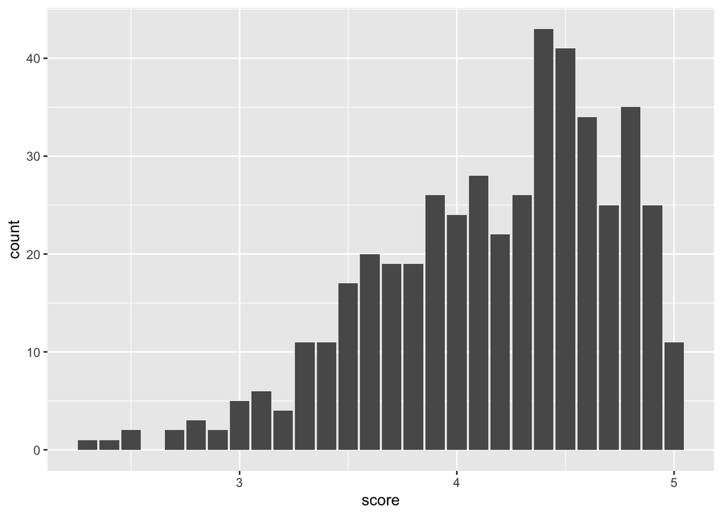

```r
ggplot(evals, aes(x = score)) +
  geom_bar()
```

```r
evals_stats <- evals %>%
  summarise(median_score = median(score), mean_score = mean(score))

evals_stats
```

```
##   median_score mean_score
## 1          4.3    4.17473
```

*The distribution is left skewed. It tells us that the majority of students rate courses with high scores. Yes, I expected to see more high scores than low scores, because students are usually satisfied of their courses.

The median score is 4.3 / 5 ( which is quite high ) and the average score is about 4.17 / 5*

2. Visualize and describe the relationship between `score` and `bty_avg` using `geom_point()` to represent the data.

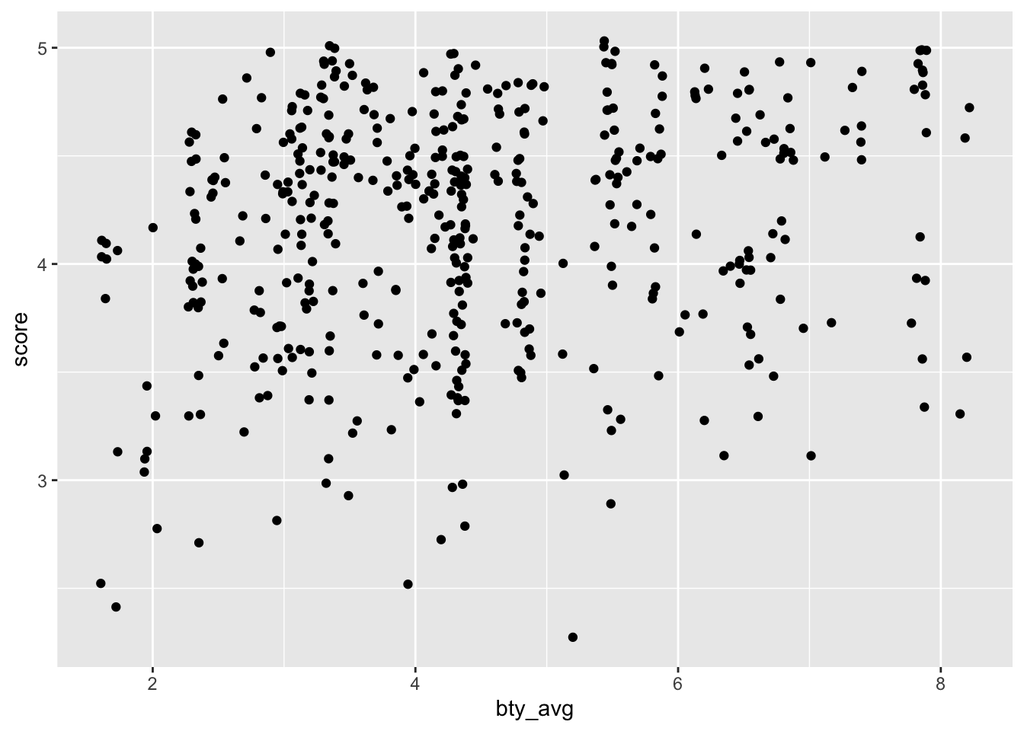

```r
ggplot(evals, aes(x = bty_avg, y = score)) +
  geom_jitter()
```